# Study of COVID-19 Vaccine Hesitancy

### Comparison of Daily change by Age range and Locations, measured in Population

```python
# data cleaning
Dose_long_diff = diff_bygroup(df = Dose_long,
             sorting_col_list=['Location', 'Category', 'Age'])
Dose_long_diff = Dose_long_diff.dropna(axis = 0)
```

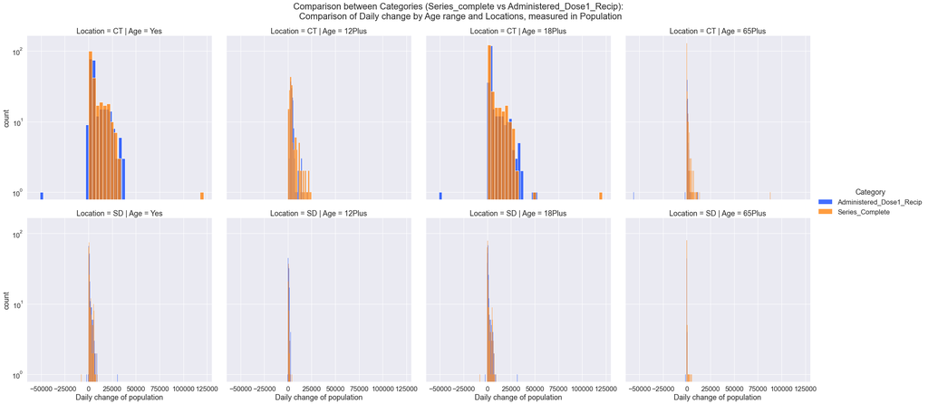

```python
# Visualization
sns.set(font_scale=1.5)
g = sns.FacetGrid(Dose_long_diff, col='Age', row = 'Location', hue = 'Category', size = 7,
                  palette=sns.color_palette('bright')[:3],
                  legend_out=True)
g.map(sns.histplot, 'diffs')

g.fig.subplots_adjust(top=0.9) # adjust the Figure in rp
g.fig.suptitle('Comparison between Categories (Series_complete vs Administered_Dose1_Recip): \n Comparison of Daily change by Age range and Locations, measured in Population')
g.set_axis_labels("Daily change of population", 'count')
g.add_legend()
g.set(yscale='log')
```

### Comparison of Time series by Age range and Locations, measured in Population proportion

- 'Administered_Dose1_Recip_Pop_Pct', 'Administered_Dose1_Recip_12PlusPop_Pct', 'Administered_Dose1_Recip_18PlusPop_Pct', 'Administered_Dose1_Recip_65PlusPop_Pct',
- 'Series_Complete_Pop_Pct', 'Series_Complete_12PlusPop_Pct', 'Series_Complete_18PlusPop_Pct', 'Series_Complete_65PlusPop_Pct',

```python
# data cleaning
Pop_Pct_Age_long = pd.melt(vacc, id_vars=['Date', 'Location'],
                    value_vars=['Administered_Dose1_Recip_Pop_Pct',
                                'Administered_Dose1_Recip_12PlusPop_Pct',
                                'Administered_Dose1_Recip_18PlusPop_Pct',
                                'Administered_Dose1_Recip_65PlusPop_Pct',
                                'Series_Complete_Pop_Pct',
                                'Series_Complete_12PlusPop_Pct',
                                'Series_Complete_18PlusPop_Pct',
                                'Series_Complete_65PlusPop_Pct',],
                           ignore_index=False)
Pop_Pct_Age_long['Category'] = Pop_Pct_Age_long.variable.str.extract('(^Administered_Dose1_Recip|^Series_Complete)')
Pop_Pct_Age_long['Pop_Pct_Age'] = Pop_Pct_Age_long.variable.str.extract('(Pop_Pct|12PlusPop_Pct|18PlusPop_Pct|65PlusPop_Pct)$')
Pop_Pct_Age_long = Pop_Pct_Age_long.reset_index(drop=True)
```

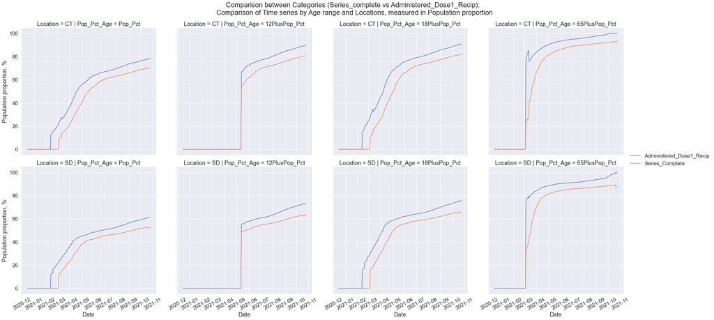

```python
# Visualization
sns.set(font_scale=1.5)
g = sns.FacetGrid(Pop_Pct_Age_long, col='Pop_Pct_Age', row = 'Location',  size = 7, legend_out=True)
g.map_dataframe(sns.lineplot, x= 'Date', y= 'value', hue = 'Category')

g.fig.subplots_adjust(top=0.9) # adjust the Figure in rp
g.fig.suptitle('Comparison between Categories (Series_complete vs Administered_Dose1_Recip): \n Comparison of Time series by Age range and Locations, measured in Population proportion')
g.set_xticklabels(rotation = 30)
g.set_axis_labels("Date", "Population proportion, %")
g.add_legend()
```

### Comparison of Daily change by Age range and Locations, measured in Population proportion

```python
# data cleaning
Pop_Pct_Age_long_diff = diff_bygroup(df = Pop_Pct_Age_long,
             sorting_col_list=['Location', 'Category', 'Pop_Pct_Age'])
Pop_Pct_Age_long_diff = Pop_Pct_Age_long_diff.dropna(axis = 0)
```

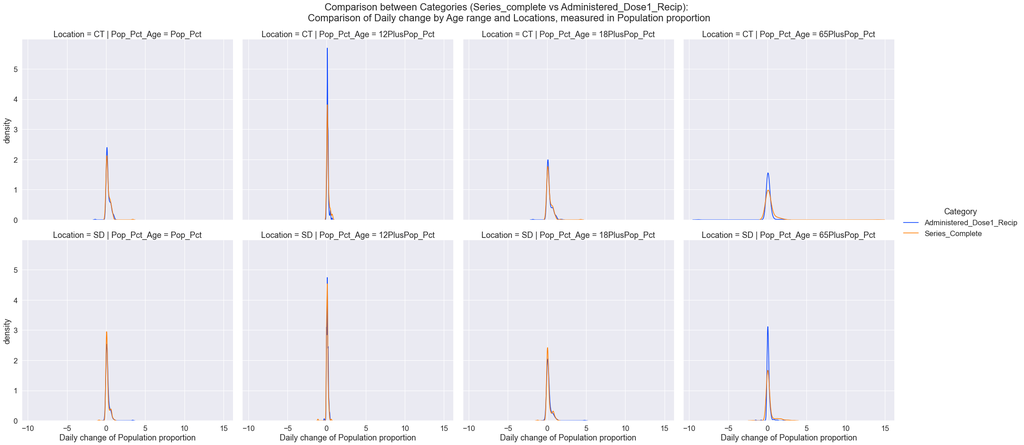

```python
# Visualization
sns.set(font_scale=1.5)
g = sns.FacetGrid(Pop_Pct_Age_long_diff, col='Pop_Pct_Age', row = 'Location', hue = 'Category', size = 7,
                  palette=sns.color_palette('bright')[:3],
                  legend_out=True)
g.map(sns.kdeplot, 'diffs')

g.fig.subplots_adjust(top=0.9) # adjust the Figure in rp
g.fig.suptitle('Comparison between Categories (Series_complete vs Administered_Dose1_Recip): \n Comparison of Daily change by Age range and Locations, measured in Population proportion')
g.set_axis_labels("Daily change of Population proportion", "density")
g.add_legend()
```

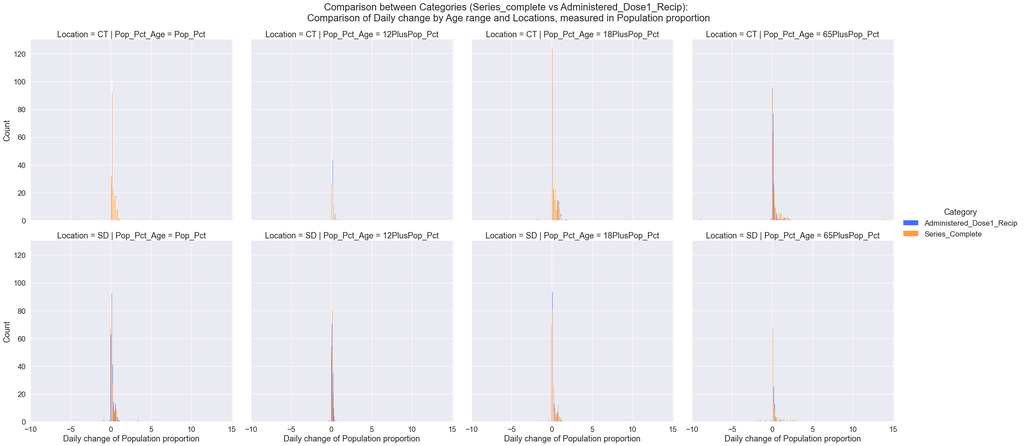

```python
# Visualization
sns.set(font_scale=1.5)
g = sns.FacetGrid(Pop_Pct_Age_long_diff, col='Pop_Pct_Age', row = 'Location', hue = 'Category', size = 7,
                  palette=sns.color_palette('bright')[:3],
                  legend_out=True)
g.map(sns.histplot, 'diffs')

g.fig.subplots_adjust(top=0.9) # adjust the Figure in rp
g.fig.suptitle('Comparison between Categories (Series_complete vs Administered_Dose1_Recip): \n Comparison of Daily change by Age range and Locations, measured in Population proportion')
g.set_axis_labels("Daily change of Population proportion", "Count")
g.add_legend()
# g.set(yscale='log')
```

## Comparison between Vaccine

### Comparison of Time series by Age range and Locations, measured in Population

'Series_Complete_Janssen', 'Series_Complete_Moderna', 'Series_Complete_Pfizer', 'Series_Complete_Unk_Manuf', 'Series_Complete_Janssen_12Plus', 'Series_Complete_Moderna_12Plus', 'Series_Complete_Pfizer_12Plus', 'Series_Complete_Unk_Manuf_12Plus', 'Series_Complete_Janssen_18Plus', 'Series_Complete_Moderna_18Plus', 'Series_Complete_Pfizer_18Plus', 'Series_Complete_Unk_Manuf_18Plus', 'Series_Complete_Janssen_65Plus', 'Series_Complete_Moderna_65Plus', 'Series_Complete_Pfizer_65Plus', 'Series_Complete_Unk_Manuf_65Plus'

```python
# data cleaning
Series_Complete_long = pd.melt(vacc, id_vars=['Date', 'Location'],
                           value_vars=['Series_Complete_Janssen',
                                       'Series_Complete_Moderna',
                                       'Series_Complete_Pfizer',
                                       'Series_Complete_Unk_Manuf',
                                       'Series_Complete_Janssen_12Plus',
                                       'Series_Complete_Moderna_12Plus',
                                       'Series_Complete_Pfizer_12Plus',
                                       'Series_Complete_Unk_Manuf_12Plus',
                                       'Series_Complete_Janssen_18Plus',
                                       'Series_Complete_Moderna_18Plus',
                                       'Series_Complete_Pfizer_18Plus',
                                       'Series_Complete_Unk_Manuf_18Plus',
                                       'Series_Complete_Janssen_65Plus',
                                       'Series_Complete_Moderna_65Plus',
                                       'Series_Complete_Pfizer_65Plus',
                                       'Series_Complete_Unk_Manuf_65Plus'],
                           ignore_index=False)
Series_Complete_long['Category'] = Series_Complete_long.variable.str.extract('(Janssen|Moderna|Pfizer|Unk_Manuf)')
Series_Complete_long['Pop_Pct_Age'] = Series_Complete_long.variable.str.extract('(12Plus|18Plus|65Plus)$')
Series_Complete_long = Series_Complete_long.reset_index(drop=True)
```

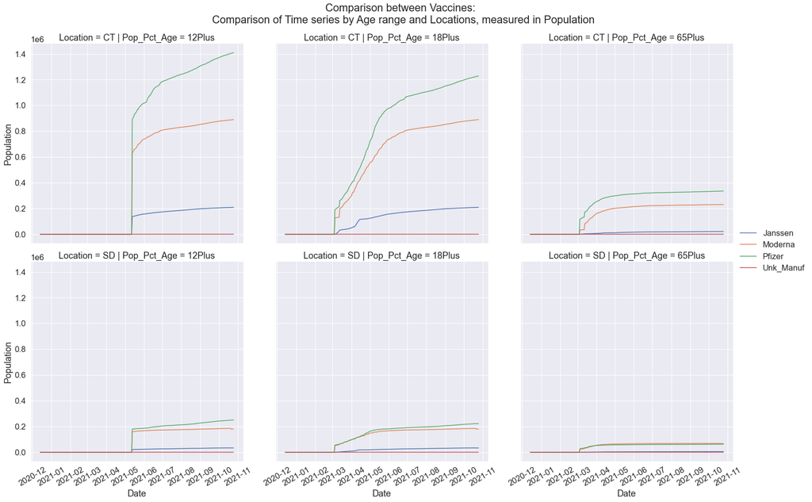

```python
# Visualization
sns.set(font_scale=1.5)
g = sns.FacetGrid(Series_Complete_long, col='Pop_Pct_Age', row = 'Location', size = 7, legend_out=True)
g.map_dataframe(sns.lineplot, x= 'Date', y= 'value', hue = 'Category')

g.fig.subplots_adjust(top=0.9) # adjust the Figure in rp
g.fig.suptitle('Comparison between Vaccines: \n Comparison of Time series by Age range and Locations, measured in Population')
g.set_xticklabels(rotation = 30)
g.set_axis_labels("Date", "Population")
g.add_legend()
```

### Comparison of Daily Change by Age range and Locations, measured in Population

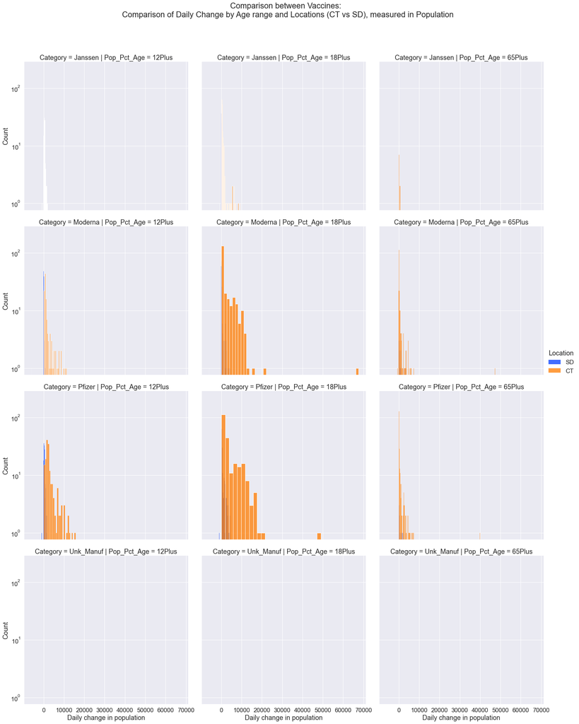

```python
# data cleaning
Series_Complete_long_diff = diff_bygroup(df = Series_Complete_long,
             sorting_col_list=['Location', 'Category', 'Pop_Pct_Age'])
Series_Complete_long_diff = Series_Complete_long_diff.dropna(axis = 0)

# Visualization
sns.set(font_scale=1.5)
g = sns.FacetGrid(Series_Complete_long_diff, col='Pop_Pct_Age', hue = 'Location',  row= 'Category', size = 7,
                  palette=sns.color_palette('bright')[:3],
                  legend_out=True)
g.map(sns.histplot, 'diffs')

g.fig.subplots_adjust(top=0.9) # adjust the Figure in rp
g.fig.suptitle('Comparison between Vaccines: \n Comparison of Daily Change by Age range and Locations (CT vs SD), measured in Population')

g.set_axis_labels("Daily change in population", "Count")
g.add_legend()
g.set(yscale='log')
```

Converting to pdf without code:

`% jupyter nbconvert --to pdf --TemplateExporter.exclude_input=True database_final_project.ipynb`